# Econometrics - Lecture 4

Diagnostic Plots & Model Assumptions

Author

Logan Kelly, Ph.D.

Published

January 26, 2025

## 1 Introduction

After establishing the fundamentals of simple linear regression and interpreting its output, it’s essential to assess the validity of the regression model’s assumptions. Diagnostic plots are powerful tools that help identify potential violations of these assumptions, ensuring that the Ordinary Least Squares (OLS) estimates remain reliable and unbiased. This lecture focuses on three key diagnostic plots: Residual Plots, QQ Plots for Normality of Residuals, and checks for Homoscedasticity (constant variance).

## 2 Key Concepts

- Residual Plots
- Normality of Residuals (QQ Plots)
- Homoscedasticity (Constant Variance Check)

## 3 Theoretical Discussion

### 3.1 Residual Plots (Identifying Patterns)

Residual plots display the residuals (differences between observed and predicted values) on the vertical axis against the fitted values or an independent variable on the horizontal axis. They help in identifying non-linearity, unequal error variances, and outliers.

- **Purpose**: To assess whether the residuals exhibit any systematic patterns.
- **Interpretation**:
  - **No Pattern**: Suggests that the linear model is appropriate.

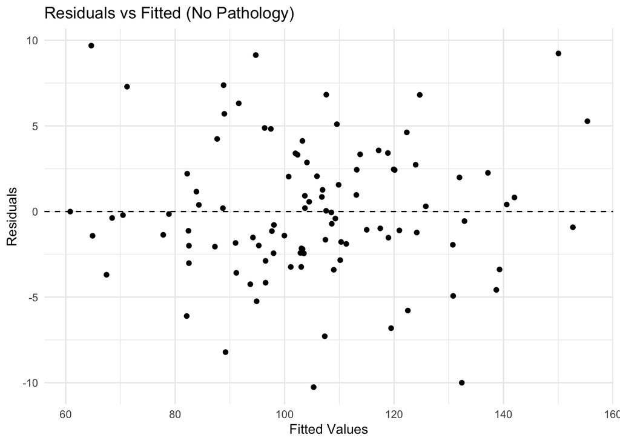

```r
# Load necessary libraries
if (!requireNamespace("pacman", quietly = TRUE)) install.packages("pacman")
pacman::p_load(ggplot2)

# Simulate data with no pathology
set.seed(100)
x <- rnorm(100, mean = 50, sd = 10)
y <- 5 + 2 * x + rnorm(100, mean = 0, sd = 5)
data_no_pathology <- data.frame(x, y)

# Fit linear model
model_no_pathology <- lm(y ~ x, data = data_no_pathology)

# Plot Residuals vs Fitted
ggplot(data_no_pathology, aes(x = fitted(model_no_pathology), y = residuals(model_no_pathology))) +
  geom_point(color = "black") +
  geom_hline(yintercept = 0, linetype = "dashed") +
  labs(title = "Residuals vs Fitted (No Pathology)",
       x = "Fitted Values",
       y = "Residuals") +
  theme_minimal()
```

- **Curvature)**: Indicates potential non-linearity.

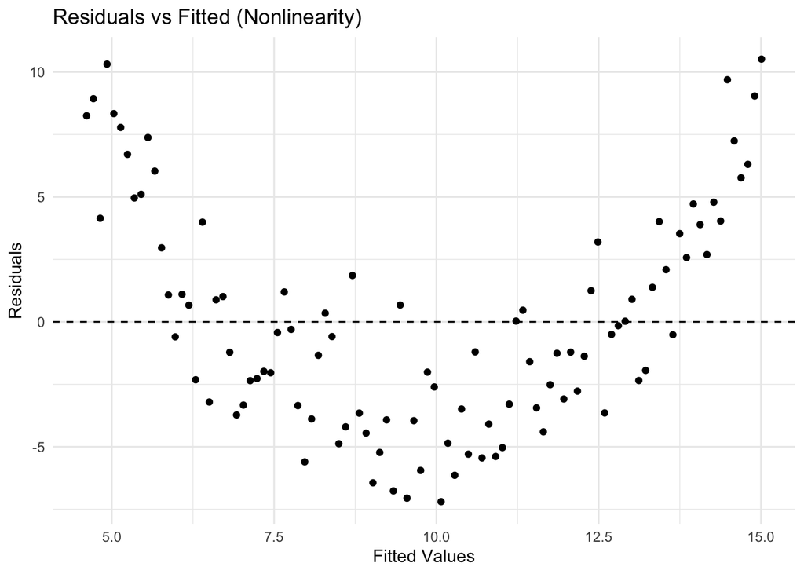

```r
# Simulate data with nonlinearity
set.seed(102)
x <- seq(-3, 3, length.out = 100)
y <- 5 + 2 * x + 1.5 * x^2 + rnorm(100, mean = 0, sd = 2)
data_nonlinear <- data.frame(x, y)

# Fit linear model
model_nonlinear <- lm(y ~ x, data = data_nonlinear)

# Plot Residuals vs Fitted
ggplot(data_nonlinear, aes(x = fitted(model_nonlinear), y = residuals(model_nonlinear))) +
  geom_point(color = "black") +
  geom_hline(yintercept = 0, linetype = "dashed") +
  labs(title = "Residuals vs Fitted (Nonlinearity)",
       x = "Fitted Values",
       y = "Residuals") +
  theme_minimal()
```

- **Funnel Shape**: Suggests heteroscedasticity (non-constant variance).

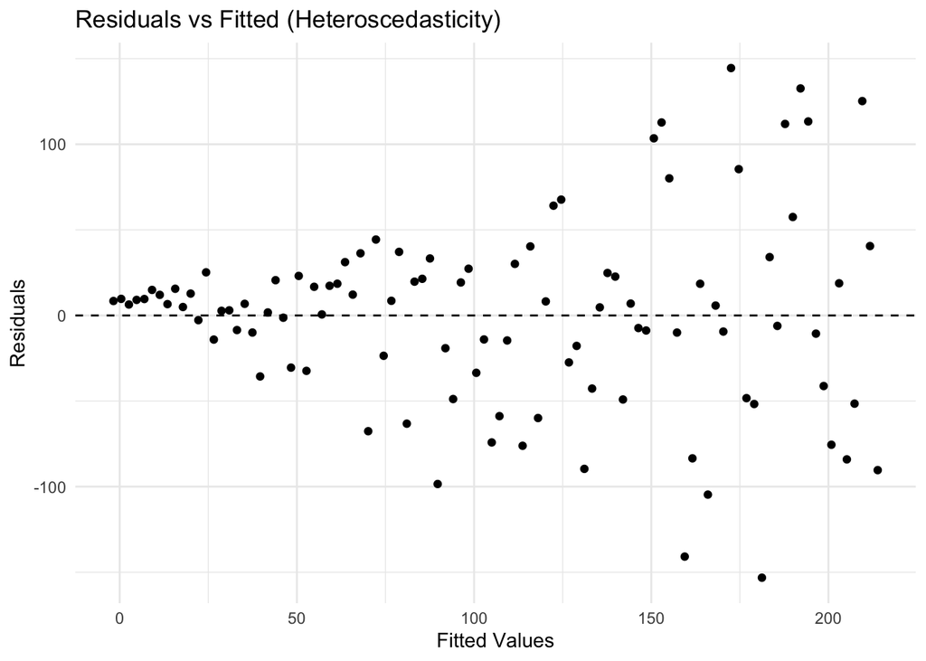

```r
# Simulate data with heteroscedasticity
set.seed(101)
x <- 1:100#rnorm(100, mean = 50, sd = 10)
y <- 5 + 2 * x + rnorm(100, mean = 0, sd = x)
data_heteroscedastic <- data.frame(x, y)

# Fit linear model
model_heteroscedastic <- lm(y ~ x, data = data_heteroscedastic)


# Plot Residuals vs Fitted
ggplot(data_heteroscedastic, aes(x = fitted(model_heteroscedastic), y = residuals(model_heteroscedastic))) +
  geom_point(color = "black") +
  geom_hline(yintercept = 0, linetype = "dashed") +
  labs(title = "Residuals vs Fitted (Heteroscedasticity)",
       x = "Fitted Values",
       y = "Residuals") +
  theme_minimal()
```

### 3.2 Normality of Residuals (QQ Plots)

QQ (Quantile-Quantile) plots compare the distribution of residuals to a normal distribution. This assessment is crucial for the validity of hypothesis tests and confidence intervals.

- **Purpose**: To check if residuals are normally distributed.
- **Interpretation**:
  - **Points Along the Line**: Residuals are approximately normally distributed.
  - **Deviations from the Line**: Indicate departures from normality, such as skewness or kurtosis.

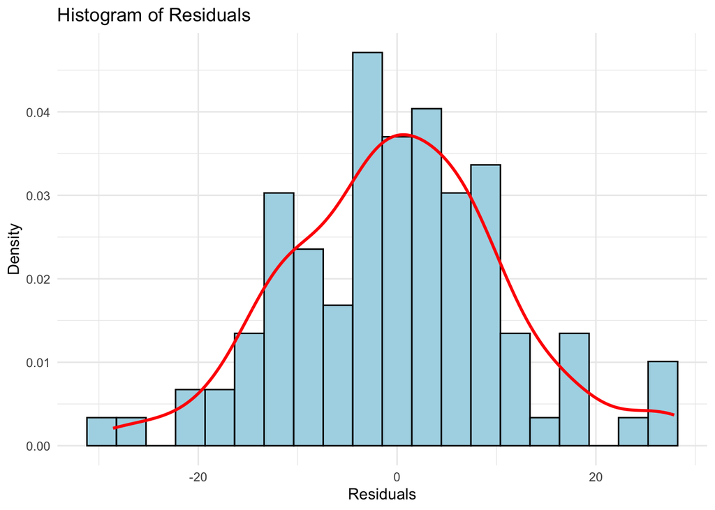

```r
# Set seed for reproducibility
set.seed(13)

# Example 1: Normal Residuals
x_normal <- rnorm(100, mean = 50, sd = 10)
y_normal <- 5 + 2 * x_normal + rnorm(100, mean = 0, sd = 10)
model_normal <- lm(y_normal ~ x_normal)
residuals_normal <- residuals(model_normal)

# Histogram
ggplot(data.frame(residuals_normal), aes(x = residuals_normal)) +
  geom_histogram(aes(y = ..density..), bins = 20, fill = "lightblue", color = "black") +
  geom_density(color = "red", size = 1) +
  labs(title = "Histogram of Residuals",
       x = "Residuals",
       y = "Density") +
  theme_minimal()
```

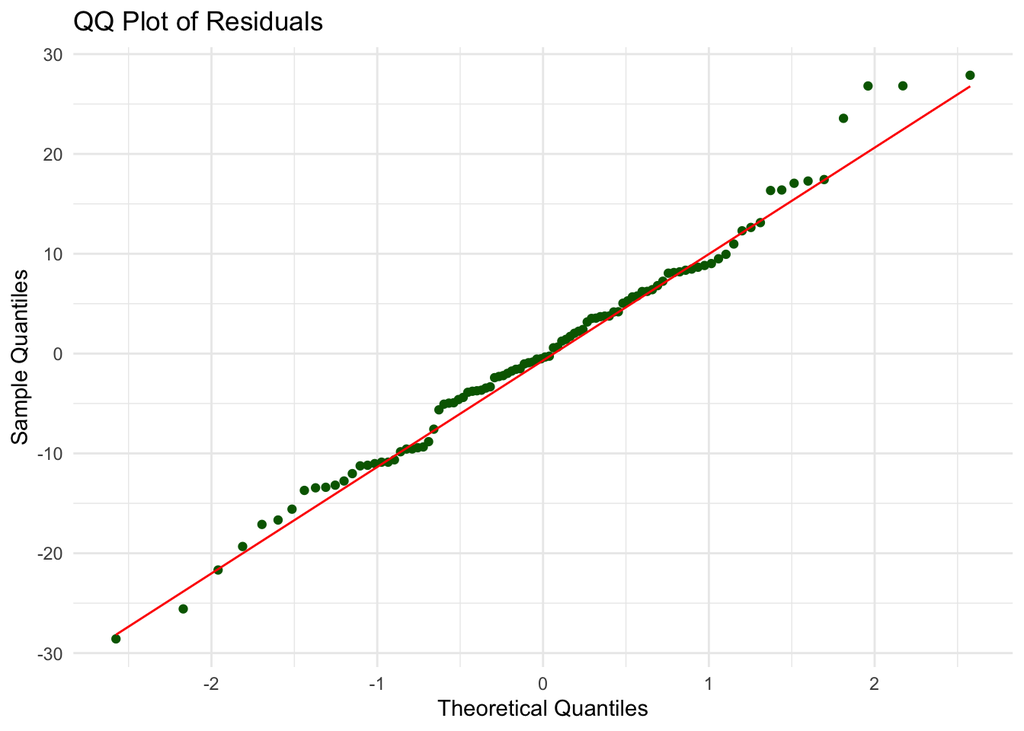

```r
# QQ Plot
ggplot(data.frame(residuals_normal), aes(sample = residuals_normal)) +
  stat_qq(color = "darkgreen") +
  stat_qq_line(color = "red") +
  labs(title = "QQ Plot of Residuals",
       x = "Theoretical Quantiles",
       y = "Sample Quantiles") +
  theme_minimal()
```

### 3.3 Homoscedasticity (Constant Variance Check)

Homoscedasticity means that the residuals have constant variance across all levels of the independent variable. Violations (heteroscedasticity) can lead to inefficient estimates and biased standard errors.

- **Purpose**: To ensure that the variance of residuals is consistent.
- **Interpretation**:
  - **Constant Spread**: Indicates homoscedasticity.
  - **Increasing or Decreasing Spread**: Suggests heteroscedasticity.

## 4 Case Study

Let’s apply these diagnostic tools to a regression model using the `mtcars` dataset, where we predict miles per gallon (`mpg`) based on weight (`wt`).

### 4.1 Step 1: Fit the Regression Model

```r
# Load the mtcars dataset
data(mtcars)

# Fit a simple linear regression model
model <- lm(mpg ~ wt, data = mtcars)

# View the summary of the model
summary(model)
```

```
Call:
lm(formula = mpg ~ wt, data = mtcars)

Residuals:
    Min      1Q  Median      3Q     Max
-4.5432 -2.3647 -0.1252  1.4096  6.8727

Coefficients:
            Estimate Std. Error t value Pr(>|t|)
(Intercept)  37.2851     1.8776  19.858  < 2e-16 ***
wt           -5.3445     0.5591  -9.559 1.29e-10 ***
---
Signif. codes:  0 '***' 0.001 '**' 0.01 '*' 0.05 '.' 0.1 ' ' 1

Residual standard error: 3.046 on 30 degrees of freedom
Multiple R-squared:  0.7528,    Adjusted R-squared:  0.7446
F-statistic: 91.38 on 1 and 30 DF,  p-value: 1.294e-10
```

### 4.2 Step 2: Generate Diagnostic Plots

#### 4.2.1 1. Residual Plot

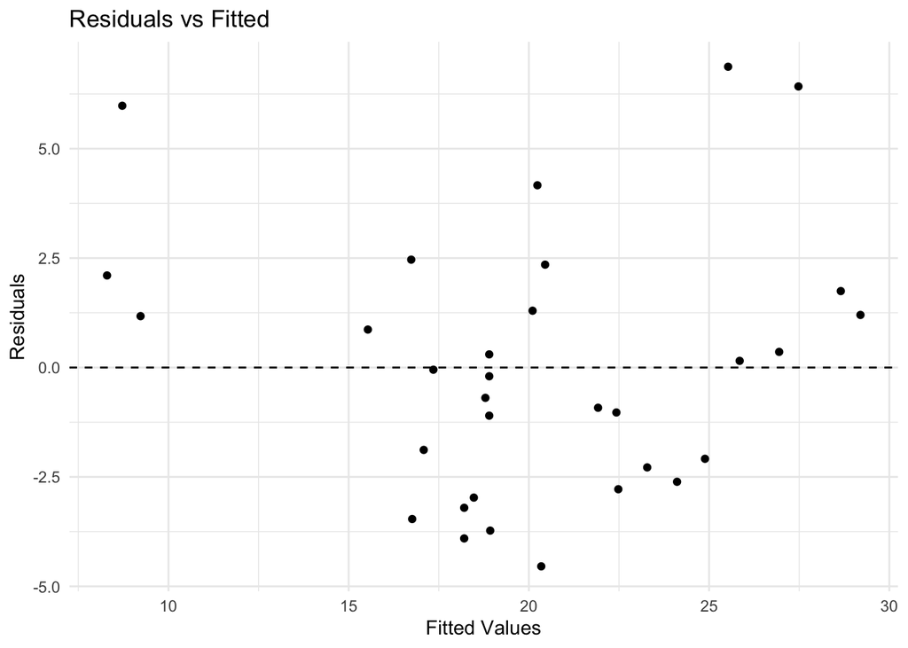

```r
# Residuals vs Fitted
ggplot(data.frame(fitted.values = model$fitted.values,
                  residuals = model$residuals),
                  aes(x = fitted.values, y = residuals)) +
  geom_point(color = "black") +
  geom_hline(yintercept = 0, linetype = "dashed") +
  labs(title = "Residuals vs Fitted",
       x = "Fitted Values",
       y = "Residuals") +
  theme_minimal()
```

#### 4.2.2 2. Normality of Residuals

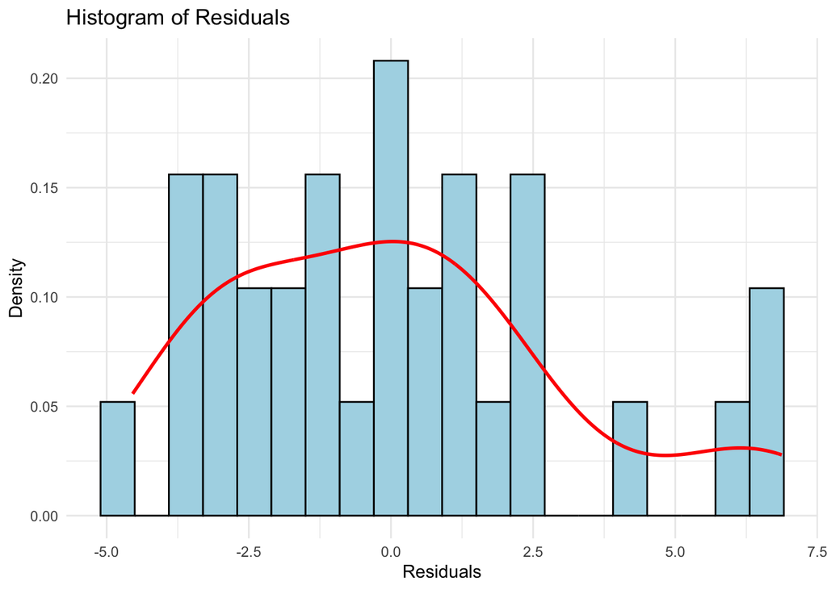

```r
# Histogram
ggplot(data.frame(residuals = model$residuals), aes(x = residuals)) +
  geom_histogram(aes(y = ..density..), bins = 20, fill = "lightblue", color = "black") +
  geom_density(color = "red", size = 1) +
  labs(title = "Histogram of Residuals",
       x = "Residuals",
       y = "Density") +
  theme_minimal()
```

### 4.3 Step 3: Annotate the Regression Table

Below is the regression table obtained from `summary(model)`:

[output not shown]

## 5 Conclusion

- Takeaway 1: **Residual Plots** help identify non-linearity, unequal error variances, and outliers, ensuring that the linear regression model is appropriate.
- Takeaway 2: **QQ Plots** assess the normality of residuals, which is vital for reliable hypothesis testing and confidence intervals.
- Takeaway 3: **Homoscedasticity Checks** ensure that the variance of residuals is constant across all levels of the independent variable, maintaining the efficiency of OLS estimates.